# ProActive

Jessie Maier

# Introduction

**`ProActive` automatically detects regions of gapped and elevated read coverage using a 2D pattern-matching algorithm. `ProActive` detects, characterizes and visualizes read coverage patterns in both genomes and metagenomes. Optionally, users may provide gene annotations associated with their genome or metagenome in the form of a .gff file. In this case, `ProActive` will generate an additional output table containing the gene annotations found within the detected regions of gapped and elevated read coverage. Additionally, users can search for gene annotations of interest in the output read coverage plots.**

Visualizing read coverage data is important because gaps and elevations in coverage can be indicators of a variety of biological and non-biological scenarios, for example-

- Elevations and gaps in read coverage may be caused by some types of structural variants. Deletions can cause gaps while duplications can cause elevations in read coverage [1].
- Highly active and/or abundant mobile genetic elements, like transposable elements [2] and prophage [3] for example, can create elevations in read coverage at their respective integration sites.
- Genetic regions with high mutation rates and/or high variability within the population can generate gaps in read coverage [4].
- Poor quality sequencing reads and chimeric reference sequences may cause gaps and elevations in read coverage.

**Since the cause for gaps and elevations in read coverage can be ambiguous, ProActive is best used as a screening method to identify genetic regions for further investigation with other tools!**

**References:**

1. Tattini L., D’Aurizio R., & Magi A. (2015). Detection of Genomic Structural Variants from Next-Generation Sequencing Data. Frontiers in bioengineering and biotechnology, 3, 92. https://doi.org/10.3389/fbioe.2015.00092
2. Kleiner M., Bushnell B., Sanderson K.E. et al. (2020) Transductomics: sequencing-based detection and analysis of transduced DNA in pure cultures and microbial communities. Microbiome 8, 158. https://doi.org/10.1186/s40168-020-00935-5
3. Kieft K., Anantharaman K. (2022). Deciphering Active Prophages from Metagenomes. mSystems 7:e00084-22. https://doi.org/10.1128/msystems.00084-22
4. Fogarty E., Moore R. (2019). Visualizing contig coverages to better understand microbial population structure. https://merenlab.org/2019/11/25/visualizing-coverages/

# Installation

## CRAN install

```r
install.packages("ProActive")
library(ProActive)
```

## GitHub install

```r
if (!require("devtools", quietly = TRUE)) {
  install.packages("devtools")
}

devtools::install_github("jlmaier12/ProActive")
library(ProActive)
```

# Input data

## Pileups

ProActive detects read coverage patterns using a pattern-matching algorithm that operates on pileup files. A pileup file is a file format where each row summarizes the ‘pileup’ of reads at specific genomic locations. Pileup files can be used to generate a rolling mean of read coverages and associated base pair positions which reduces data size while preserving read coverage patterns. **ProActive requires that input pileups files** **be generated using a 100 bp window/bin size.**

Pileup files are generated using the .bam files produced after mapping sequencing reads to a metagenome or genome fasta file. **Read mapping should be performed using a high** **minimum identity (0.97 or higher) and random mapping of ambiguous reads.**

Some read mappers, like [BBMap](https://jgi.doe.gov/data-and-tools/software-tools/bbtools/bb-tools-user-guide/bbmap-guide/), allow for the generation of pileup files in the [`bbmap.sh`](https://github.com/BioInfoTools/BBMap/blob/master/sh/bbmap.sh) command with use of the `bincov` output with the `covbinsize=100` parameter/argument. **Otherwise, BBMap’s** **[`pileup.sh`](https://github.com/BioInfoTools/BBMap/blob/master/sh/pileup.sh)** **can convert .bam files produced by any read mapper to pileup files compatible** **with ProActive using the `bincov` output with `binsize=100`.**

**The input pileup file for metagenomes must have the following format:**

Dataframe with four columns:

- V1: Contig accession
- V2: Mapped read coverage values averaged over 100 bp windows
- V3: Starting position (bp) of each 100 bp window. Restarts from 100 at the start of each new contig.
- V4: Starting position (bp) of each 100 bp window. Does NOT restart at the start of each new contig.

| V1 | V2 | V3 | V4 |
| --- | --- | --- | --- |
| NODE_1911 length_44214_cov_4.82142_ID_9560073 | 54.66 | 100 | 175075473 |
| NODE_1911 length_44214_cov_4.82142_ID_9560073 | 59.13 | 200 | 175075573 |
| NODE_1911 length_44214_cov_4.82142_ID_9560073 | 53.99 | 300 | 175075673 |
| NODE_1911 length_44214_cov_4.82142_ID_9560073 | 54.69 | 400 | 175075773 |
| NODE_1911 length_44214_cov_4.82142_ID_9560073 | 54.40 | 500 | 175075873 |
| NODE_1911 length_44214_cov_4.82142_ID_9560073 | 52.11 | 600 | 175075973 |

**Note that the format for a genome pileup will be slightly different! The third** **column (V3) does not restart and the fourth column (V4) starts from 0. ProActive** **accounts for the differences in pileup formats between genomes and metagenomes.**

Users may use the ‘sampleMetagenomePileup’ and ‘sampleGenomePileup’ files that come pre-loaded with ProActive as references for proper input file format.

## gff TSV

Optionally, ProActive will accept a .gff file as additional input. The .gff file must be associated with the same metagenome or genome used to create your pileup file. The .gff file should be in TSV format and should follow the same layout described [here](https://en.wikipedia.org/wiki/General_feature_format#:~:text=In%20bioinformatics%2C%20the%20general%20feature,DNA%2C%20RNA%20and%20protein%20sequences.).

**The input .gff file must have the following format exactly:**

V1

V2

V3

V4

V5

V6

V7

V8

V9

NODE_1911

Prodigal:002006

CDS

318

1166

.

0

ID=NJKKNKEE_164175;inference=ab initio prediction:Prodigal:002006;locus_tag=NJKKNKEE_164175;product=hypothetical protein

NODE_1911

Prodigal:002006

CDS

1198

1938

.

0

ID=NJKKNKEE_164176;inference=ab initio prediction:Prodigal:002006;locus_tag=NJKKNKEE_164176;product=hypothetical protein

NODE_1911

Prodigal:002006

CDS

1938

2582

.

0

ID=NJKKNKEE_164177;inference=ab initio prediction:Prodigal:002006;locus_tag=NJKKNKEE_164177;product=hypothetical protein

NODE_1911

Prodigal:002006

CDS

2722

3561

.

0

ID=NJKKNKEE_164178;inference=ab initio prediction:Prodigal:002006;locus_tag=NJKKNKEE_164178;product=hypothetical protein

NODE_1911

Prodigal:002006

CDS

3671

4063

.

0

ID=NJKKNKEE_164179;inference=ab initio prediction:Prodigal:002006;locus_tag=NJKKNKEE_164179;product=hypothetical protein

NODE_1911

Prodigal:002006

CDS

4128

4670

.

0

ID=NJKKNKEE_164180;eC_number=1.11.1.1;Name=rbr1_24;db_xref=COG:COG1592;gene=rbr1_24;inference=ab initio prediction:Prodigal:002006,similar to AA sequence:UniProtKB:Q97FZ9;locus_tag=NJKKNKEE_164180;product=Rubrerythrin-1

(**Hint**- if you are using a gff file output by [PROKKA](https://github.com/tseemann/prokka), you may need to remove some unnecessary (for ProActive) lines of text at the top of the file. There are various ways one can remove these additional lines, however, a nice command-line solution is:)

```bash
grep ^COMMONID metagenomeAnnots.gff > metagenomeAnnotsForProActive.gff
```

The ‘COMMONID’ should be a value that all of your contig or genome accessions start with. For example, the ‘COMMONID’ for the contig accessions in the sampleMetagenomegffTSV displayed above could be “NODE” since all the accessions start with “NODE”.

# ProActiveDetect()

`ProActiveDetect()` is the main function in the ProActive R package. This function filters contigs/chunks based on length and read coverage, performs pattern-matching to detect gaps and elevations in read coverage, identifies start and stop positions and sizes of pattern-matches, and, optionally, extracts gene annotations that fall within detect gaps and elevations in read coverage.

## Function components

### Chunking

Currently, `ProActiveDetect()` can only detect one gap or elevation pattern per contig. Until `ProActiveDetect()` is able to detect multiple read coverage patterns per contig, we implemented a ‘chunking’ functionality which (if `chunkContigs` = TRUE) chunks large contigs into smaller subsets (defined by `chunkSize`) so that pattern-matching can be performed on each chunk as if it were an individual contig. The chunking mechanism is what allows `ProActiveDetect()` to perform pattern-matching on entire genome sequences. When contigs/genomes are chunked, they are assigned a sequential value to link chunks back together (i.e. “NODE_1_chunk_1, NODE_1_chunk_2, NODE_1_chunk_3, …). Note that the remaining ‘chunk’ of a contig/genome may not be long enough to perform pattern-matching on. Chunks too small for pattern-matching will be put in the output FilteredOut table. If a chunk splits a gap or elevation pattern in half, `ProActiveDetect()` will attempt to detect this and report it to the user as a ‘possible pattern-match continuity’ between contig/genome chunks. Pattern-match continuity is detected when two sequential chunks have a partial elevation/gap pattern going off the right and left side of the chunks, respectively.

### Filtering

Contigs/chunks that are too short or have little to no read coverage are filtered out prior to pattern-matching. `ProActiveDetect()` filters out contigs/chunks that do not have at least 10x coverage on a total of 5,000 bp across the whole contig/chunk. The read coverage filtering was done in this way to avoid filtering out long contigs/chunks with small elevations in read coverage that might get removed if filtering was done with read coverage averages or medians. Additionally, contigs/chunks less than 30,000 bp are filtered out by default, however this can be changed with the `minContigLength` parameter which can be set to a minimum of 25,000 bp. **If you would like to reduce the size of your input metagenome pileup file for** **`ProActiveDetect()`, consider pre-filtering your assembly for contigs greater than** **25,000 bp prior to read mapping!**

### Changing pileup windowSize

The input pileup files have 100 bp windows in which the mapped read coverage is averaged over. `ProActiveDetect()` increases the window size prior to pattern-matching by averaging the read coverages over a value specified with `windowSize`. In many cases, read coverage patterns don’t require the resolution that 100 bp windows provide, however, starting with a 100 bp windowSize means the higher resolution is available if needed. While users can use the 100 bp `windowSize` for `ProActiveDetect()`, the processing time will be increased **significantly** and noisy data may interfere with pattern-matching. We find that the default 1,000 bp `windowSize` provides a nice balance between processing time and read coverage pattern resolution. If you’d like more resolution than the 1,000 bp `windowSize` provides, consider dropping the `windowSize` to 500. If you’d like fine scale read coverage resolution, consider viewing the contigs/genome with a software like Integrative Genomics Viewer [IGV](https://github.com/igvteam/igv).

### Pattern-matching

`ProActiveDetect()` detects read coverage patterns using a 2D pattern-matching algorithm. Several predefined patterns, described below, are built using the specific length and read coverage values of the contig/chunk being assessed. Patterns are translated across each contig/chunk in 1,000 bp sliding windows and at each translation, a pattern-match score is calculated by taking the mean absolute difference of the read coverage and the pattern values. The smaller the match-score, the better the pattern-match. After a pattern is fully translated across a contig/chunk, certain aspects of the pattern are changed (i.e. height, base, width) and translation is repeated. This process of translation and pattern re-scaling is repeated until a large number of pattern variations are tested. After pattern-matching is complete, the pattern associated with the best match-score is used for contig/chunk classification. Contigs/chunks are classified as ‘Elevation’, ‘Gap’, or ‘NoPattern’ during pattern-matching.

#### Elevation pattern:

The ‘elevation’ class is defined by a ‘block’ pattern. During pattern-matching, the height (max.), base (min.) and width are altered and all pattern variations are translated across the contig/chunk. The block width never gets smaller than 10,000 bp by default, however this can be changed with the `minSize` parameter.

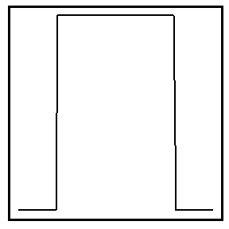

#### Gap pattern:

The ‘gap’ class is essentially the reverse of the values used to build the block pattern in the ‘elevation’ class. The same pattern-matching steps (alteration of pattern max., min. and width values and pattern translation) used for the elevation pattern are used for the gap pattern.

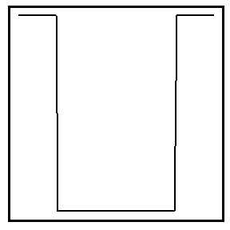

#### Elevation/Gap pattern:

Elevations and gaps that trail off one side of a contig/chunk are hard to classify as the read coverage can be interpreted as a gap or elevation depending on how you’re looking at it. We classify contigs/chunk as ‘Gap’ if the elevated region is greater than 50% of the length of the contig/chunk. Conversely, if the elevated region is less than 50% of the contig/chunk length, the classification is ‘Elevation’.

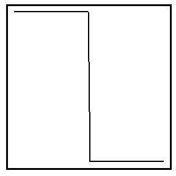

#### noPattern:

Since the best pattern-match for each contig/chunk is determined by comparing match-scores amongst all pattern-variations from all pattern classes, we needed a ‘negative control’ pattern to compare against. The ‘NoPattern’ ‘pattern’ serves as a negative control by matching to contigs/chunks with no read coverage patterns. We made two NoPattern patterns which consist of a horizontal line the same length as the contig/chunk being assessed at the contig/chunk’s average and median read coverage value. This pattern is not re-scaled or translated in any way.

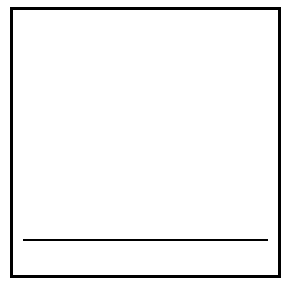